# Classify Default Clients - Credit Card Data

$\it{Developed~by~Weiting~Ho~@July~2020}$

[figure not shown]

## Data Overview: **[[Reference: UCI Machine Learning Repository]](https://archive.ics.uci.edu/ml/datasets/default+of+credit+card+clients#)**

- DEFAULT: Whether the user default the next month payment (No = 0, Yes = 1).
- LIMIT_BAL: Amount of the given credit (NT dollar). It includes both the individual consumer credit and his/her family (supplementary) credit.
- SEX: Male of female (1 = male, 2 = female).
- EDUCATION: Consumer's highest education level (1 = graduate school; 2 = university; 3 = high school; 4 = others).
- MARRIAGE: Marital status (1 = married; 2 = single; 3 = divorce; 4 = others).
- AGE: Age in year.
- PAY_0 to PAY_6: History of past payment (-2 = no consumption; -1 = pay duly; 0 = the use of revolving credit; 1 = payment delay for one month; 2 = payment delay for two months; . . .; 8 = payment delay for eight months; 9 = payment delay for nine months and above).
- BILL_AMT1 to BILL_AMT6: Amount of bill statement (NT dollar).
- PAY_AMT1 to PAY_AMT6: Amount of previous payment (NT dollar).

```python
import numpy as np
import pandas as pd
import matplotlib.pyplot as plt
import seaborn as sns
sns.set(color_codes=True)
from itertools import product
from sklearn.utils import resample
import scipy.stats as ss
from sklearn.utils import shuffle
import warnings
warnings.filterwarnings('ignore')
```

```python
raw_df = pd.read_csv('dccc.csv', index_col=0)
col = raw_df.columns.tolist()
col = col[-1:] + col[:-1]
raw_df = raw_df[col]
col_dict = {
    'default payment next month': 'DEFAULT',
    'PAY_0': 'PAY_9',
    'PAY_2': 'PAY_8',
    'PAY_3': 'PAY_7',
    'PAY_4': 'PAY_6',
    'PAY_5': 'PAY_5',
    'PAY_6': 'PAY_4',
    'BILL_AMT1': 'BILL_AMT9',
    'BILL_AMT2': 'BILL_AMT8',
    'BILL_AMT3': 'BILL_AMT7',
    'BILL_AMT4': 'BILL_AMT6',
    'BILL_AMT5': 'BILL_AMT5',
    'BILL_AMT6': 'BILL_AMT4',
    'PAY_AMT1': 'PAY_AMT9',
    'PAY_AMT2': 'PAY_AMT8',
    'PAY_AMT3': 'PAY_AMT7',
    'PAY_AMT4': 'PAY_AMT6',
    'PAY_AMT5': 'PAY_AMT5',
    'PAY_AMT6': 'PAY_AMT4'
}
raw_df = raw_df.rename(col_dict, axis=1)
```

```python
raw_df.head()
```

| ID | DEFAULT | LIMIT_BAL | SEX | EDUCATION | MARRIAGE | AGE | PAY_9 | PAY_8 | PAY_7 | PAY_6 | ... | BILL_AMT7 | BILL_AMT6 | BILL_AMT5 | BILL_AMT4 | PAY_AMT9 | PAY_AMT8 | PAY_AMT7 | PAY_AMT6 | PAY_AMT5 | PAY_AMT4 |
| --- | --- | --- | --- | --- | --- | --- | --- | --- | --- | --- | --- | --- | --- | --- | --- | --- | --- | --- | --- | --- | --- |
| 1 | 1 | 20000 | 2 | 2 | 1 | 24 | 2 | 2 | -1 | -1 | ... | 689 | 0 | 0 | 0 | 0 | 689 | 0 | 0 | 0 | 0 |
| 2 | 1 | 120000 | 2 | 2 | 2 | 26 | -1 | 2 | 0 | 0 | ... | 2682 | 3272 | 3455 | 3261 | 0 | 1000 | 1000 | 1000 | 0 | 2000 |
| 3 | 0 | 90000 | 2 | 2 | 2 | 34 | 0 | 0 | 0 | 0 | ... | 13559 | 14331 | 14948 | 15549 | 1518 | 1500 | 1000 | 1000 | 1000 | 5000 |
| 4 | 0 | 50000 | 2 | 2 | 1 | 37 | 0 | 0 | 0 | 0 | ... | 49291 | 28314 | 28959 | 29547 | 2000 | 2019 | 1200 | 1100 | 1069 | 1000 |
| 5 | 0 | 50000 | 1 | 2 | 1 | 57 | -1 | 0 | -1 | 0 | ... | 35835 | 20940 | 19146 | 19131 | 2000 | 36681 | 10000 | 9000 | 689 | 679 |

5 rows × 24 columns

## Data Preprocessing

This section contains:

- Dealing with missing value
- Explore the data with visualization
- Data scaling

### Missing Values

```python
np.random.seed(123)
rows = np.random.randint(0, 30000, 5000)
df = raw_df.loc[rows].copy().reset_index(drop=True)

# Randomly replace 6% of records with NaN
df.iloc[:, 1:] = df.iloc[:, 1:].mask(
    np.random.random((df.shape[0], df.shape[1] - 1)) < 0.06)
tot_nan = df.isnull().sum().sum()

print('The distribution of NaN across each column:')
print(df.isnull().sum())
print(
    '\nAfter randomly replacing missing values, we now have {0} NaN\'s across the dataset, it\'s approximate to the proportion of {1:.1%} in the dataset.'
    .format(tot_nan, tot_nan / (df.shape[0] * df.shape[1])))
```

```
The distribution of NaN across each column:
DEFAULT        0
LIMIT_BAL    297
SEX          274
EDUCATION    301
MARRIAGE     315
AGE          315
PAY_9        310
PAY_8        309
PAY_7        314
PAY_6        286
PAY_5        286
PAY_4        263
BILL_AMT9    315
BILL_AMT8    282
BILL_AMT7    298
BILL_AMT6    286
BILL_AMT5    294
BILL_AMT4    303
PAY_AMT9     279
PAY_AMT8     293
PAY_AMT7     281
PAY_AMT6     321
PAY_AMT5     319
PAY_AMT4     337
dtype: int64

After randomly replacing missing values, we now have 6878 NaN's across the dataset, it's approximate to the proportion of 5.7% in the dataset.
```

```python
df.fillna(df.median(), inplace=True)

# Check NULL values
print('After dealing with missing values, we got {} NaN now.'.format(df.isnull().sum().sum()))
```

```
After dealing with missing values, we got 0 NaN now.
```

### Exploratory Data Analysis

```python
df.info()
```

```
<class 'pandas.core.frame.DataFrame'>
RangeIndex: 5000 entries, 0 to 4999
Data columns (total 24 columns):
 #   Column     Non-Null Count  Dtype
---  ------     --------------  -----
 0   DEFAULT    5000 non-null   int64
 1   LIMIT_BAL  5000 non-null   float64
 2   SEX        5000 non-null   float64
 3   EDUCATION  5000 non-null   float64
 4   MARRIAGE   5000 non-null   float64
 5   AGE        5000 non-null   float64
 6   PAY_9      5000 non-null   float64
 7   PAY_8      5000 non-null   float64
 8   PAY_7      5000 non-null   float64
 9   PAY_6      5000 non-null   float64
```

[output cut: 16 more lines]

```python
col = ['DEFAULT', 'SEX', 'EDUCATION', 'MARRIAGE']
for c in col:
    df[c] = df[c].astype('category')

col = ['PAY_9', 'PAY_8', 'PAY_7', 'PAY_6', 'PAY_5', 'PAY_4']
for c in col:
    df[c] = df[c].astype('int').astype('category')

df.info()
```

```
<class 'pandas.core.frame.DataFrame'>
RangeIndex: 5000 entries, 0 to 4999
Data columns (total 24 columns):
 #   Column     Non-Null Count  Dtype
---  ------     --------------  -----
 0   DEFAULT    5000 non-null   category
 1   LIMIT_BAL  5000 non-null   float64
 2   SEX        5000 non-null   category
 3   EDUCATION  5000 non-null   category
 4   MARRIAGE   5000 non-null   category
 5   AGE        5000 non-null   float64
 6   PAY_9      5000 non-null   category
 7   PAY_8      5000 non-null   category
 8   PAY_7      5000 non-null   category
 9   PAY_6      5000 non-null   category
```

[output cut: 16 more lines]

```python
df.describe()
```

|  | LIMIT_BAL | AGE | BILL_AMT9 | BILL_AMT8 | BILL_AMT7 | BILL_AMT6 | BILL_AMT5 | BILL_AMT4 | PAY_AMT9 | PAY_AMT8 | PAY_AMT7 | PAY_AMT6 | PAY_AMT5 | PAY_AMT4 |
| --- | --- | --- | --- | --- | --- | --- | --- | --- | --- | --- | --- | --- | --- | --- |
| count | 5000.000000 | 5000.000000 | 5000.000000 | 5000.000000 | 5.000000e+03 | 5000.000000 | 5000.000000 | 5000.000000 | 5000.000000 | 5.000000e+03 | 5000.000000 | 5000.000000 | 5000.000000 | 5000.000000 |
| mean | 165704.736000 | 35.274400 | 51309.430000 | 48356.856000 | 4.705027e+04 | 43106.284000 | 40309.093400 | 38444.022200 | 5248.929600 | 5.796630e+03 | 5427.431400 | 4938.373000 | 4898.910200 | 5061.581000 |
| std | 126043.341309 | 8.754041 | 75443.829846 | 71884.416962 | 7.310346e+04 | 65639.900831 | 62158.399864 | 60663.654318 | 13410.480203 | 2.824641e+04 | 17367.142673 | 16230.434104 | 16985.104826 | 17481.966303 |
| min | 10000.000000 | 21.000000 | -10682.000000 | -18618.000000 | -2.470200e+04 | -170000.000000 | -81334.000000 | -339603.000000 | 0.000000 | 0.000000e+00 | 0.000000 | 0.000000 | 0.000000 | 0.000000 |
| 25% | 60000.000000 | 29.000000 | 4573.000000 | 3878.250000 | 3.739500e+03 | 3239.250000 | 2645.250000 | 1694.000000 | 1043.500000 | 1.000000e+03 | 628.000000 | 390.000000 | 316.000000 | 291.000000 |
| 50% | 140000.000000 | 34.000000 | 23764.000000 | 22140.500000 | 2.119000e+04 | 19584.000000 | 18810.000000 | 17538.000000 | 2198.000000 | 2.100000e+03 | 2000.000000 | 1500.000000 | 1511.000000 | 1500.000000 |
| 75% | 230000.000000 | 41.000000 | 62052.250000 | 58918.000000 | 5.654800e+04 | 50665.750000 | 48622.750000 | 47152.500000 | 5000.000000 | 5.000000e+03 | 4438.500000 | 4000.000000 | 4000.000000 | 3981.000000 |
| max | 800000.000000 | 73.000000 | 626648.000000 | 743970.000000 | 1.664089e+06 | 628699.000000 | 823540.000000 | 527566.000000 | 300000.000000 | 1.684259e+06 | 417588.000000 | 497000.000000 | 388071.000000 | 377000.000000 |

```python
df.head()
```

|  | DEFAULT | LIMIT_BAL | SEX | EDUCATION | MARRIAGE | AGE | PAY_9 | PAY_8 | PAY_7 | PAY_6 | ... | BILL_AMT7 | BILL_AMT6 | BILL_AMT5 | BILL_AMT4 | PAY_AMT9 | PAY_AMT8 | PAY_AMT7 | PAY_AMT6 | PAY_AMT5 | PAY_AMT4 |
| --- | --- | --- | --- | --- | --- | --- | --- | --- | --- | --- | --- | --- | --- | --- | --- | --- | --- | --- | --- | --- | --- |
| 0 | 0 | 270000.0 | 2.0 | 2.0 | 1.0 | 34.0 | 0 | 0 | 0 | 0 | ... | 55382.0 | 46629.0 | 28115.0 | 12847.0 | 5168.0 | 5010.0 | 2005.0 | 2000.0 | 2000.0 | 2000.0 |
| 1 | 0 | 140000.0 | 2.0 | 2.0 | 2.0 | 38.0 | 0 | 0 | 0 | 2 | ... | 21190.0 | 140617.0 | 139353.0 | 140953.0 | 6010.0 | 12500.0 | 4009.0 | 5000.0 | 1511.0 | 5300.0 |
| 2 | 0 | 50000.0 | 2.0 | 2.0 | 1.0 | 34.0 | -2 | -1 | 0 | 0 | ... | 50710.0 | 50503.0 | 40140.0 | -21364.0 | 50702.0 | 2033.0 | 1776.0 | 2000.0 | 29000.0 | 59901.0 |
| 3 | 0 | 220000.0 | 2.0 | 2.0 | 1.0 | 51.0 | 0 | 0 | 0 | 0 | ... | 8605.0 | 5352.0 | -5048.0 | -5048.0 | 3010.0 | 3040.0 | 1000.0 | 0.0 | 0.0 | 0.0 |
| 4 | 1 | 100000.0 | 2.0 | 2.0 | 1.0 | 35.0 | 2 | 2 | 2 | 2 | ... | 21190.0 | 97997.0 | 103384.0 | 97266.0 | 5500.0 | 8200.0 | 0.0 | 8000.0 | 0.0 | 8600.0 |

5 rows × 24 columns

**Re-define the categorical data**

```python
df['EDUCATION'].replace([0, 5, 6], 4, inplace=True)
df['MARRIAGE'].replace(0, 4, inplace=True)
```

**Show the distribution between whether or not customers are default**

```
There are 22.40% risky customers (targets) in our data.
The ratio of risky to non-risky is 28.87%
```

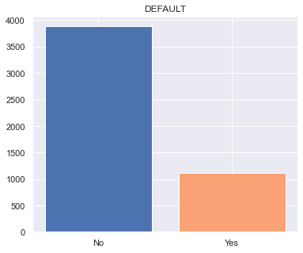

```python
plt.figure(figsize=(6, 5))
x_axis = ['No', 'Yes']
y_axis = df['DEFAULT'].value_counts().tolist()
plt.bar(x_axis, y_axis, color=('b', '#faa275'))
plt.title('DEFAULT')
print('There are {:.2%} risky customers (targets) in our data.'.format(sum(df.DEFAULT)/len(df.DEFAULT)))
print('The ratio of risky to non-risky is {:.2%}'.format(df.DEFAULT.value_counts()[1]/df.DEFAULT.value_counts()[-2]))
```

**Show the distribution on SEX, EDUCATION, and MARRIAGE variables grouped by DEFAULT.**

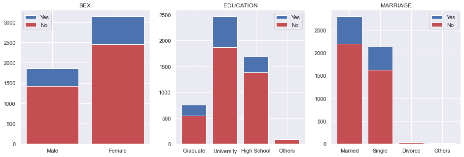

```python
fig, axes = plt.subplots(ncols=3, nrows=1, figsize=(16, 5))

k = ['SEX', 'EDUCATION', 'MARRIAGE']
v = [['Male', 'Female'], ['Graduate', 'University', 'High School', 'Others'],
     ['Married', 'Single', 'Divorce', 'Others']]
p = [0, 1, 2]

for kol, val, pos in zip(k, v, p):
    plt.sca(axes[pos])
    x_axis = df[kol].unique().tolist()
    y_axis_0 = df[kol][df.DEFAULT == 0].value_counts().tolist()
    y_axis_1 = df[kol][df.DEFAULT == 1].value_counts().tolist()
    p1 = plt.bar(x_axis, y_axis_0, color = 'r')
    p2 = plt.bar(x_axis, y_axis_1, bottom=y_axis_0, color = 'b')
    plt.title(kol)
    plt.legend((p2[0], p1[0]), ('Yes', 'No'), loc='best')
    plt.xticks(np.arange(1, len(val) + 1), val)
```

**Show the distribution on LIMIT_BAL and AGE**

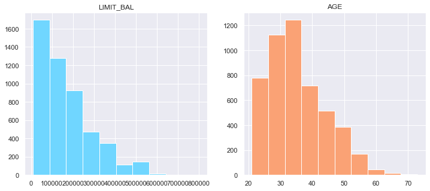

```python
fig, axes = plt.subplots(ncols=2, nrows=1, figsize=(12, 5))
k = ['LIMIT_BAL', 'AGE']
p = [0, 1]
c = ['#70d6ff', '#faa275']

for kol, pos, col in zip(k, p, c):
    plt.sca(axes[pos])
    plt.hist(df[kol], color=col)
    plt.title(kol)
```

**Show the distribution on AGE and LIMIT_BAL grouped by DEFAULT.**

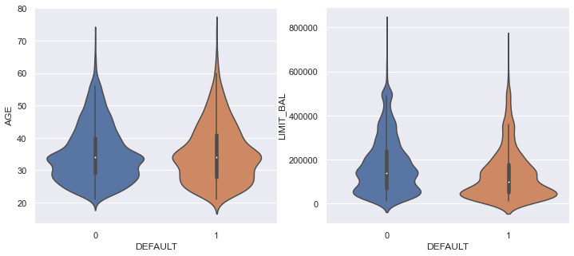

```python
fig, axes = plt.subplots(ncols=2, nrows=1, figsize=(12, 5))

k = ['AGE', 'LIMIT_BAL']
p = [0, 1]

for kol, pos in zip(k, p):
    plt.sca(axes[pos])
    sns.violinplot(df.DEFAULT, df[kol])
```

**Correlation between all numerical columns**

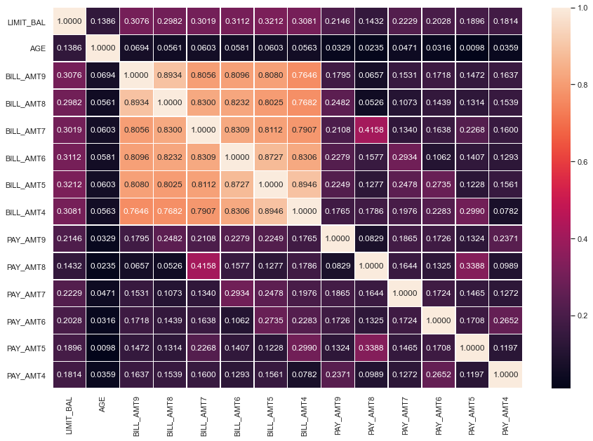

```python
plt.figure(figsize=(15,10))
sns.heatmap(df.corr(), annot=True, fmt='.4f', linewidths=.5)
plt.show()
```

Remove high correlation features to avoid collinearity issue.

**Correlation between all categorical columns**

```python
def cramers_v(x, y):
    """
    calculate Cramers V statistic for categorial-categorial association.
    uses correction from Bergsma and Wicher,
    Journal of the Korean Statistical Society 42 (2013): 323-328
    """
    confusion_matrix = pd.crosstab(x,y)
    chi2 = ss.chi2_contingency(confusion_matrix)[0]
    n = confusion_matrix.sum().sum()
    phi2 = chi2/n
    r,k = confusion_matrix.shape
    phi2corr = max(0, phi2-((k-1)*(r-1))/(n-1))
    rcorr = r-((r-1)**2)/(n-1)
    kcorr = k-((k-1)**2)/(n-1)
    return np.sqrt(phi2corr/min((kcorr-1),(rcorr-1)))
```

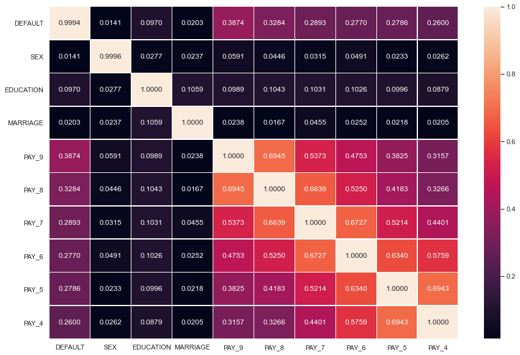

```python
corr_mat_catcat = []
df_cat = df.select_dtypes(include = ['category'])
for i in df_cat.columns:
    for j in df_cat.columns:
        corr_mat_catcat.append(cramers_v(df[i], df[j]))

corr_mat_catcat = np.array(corr_mat_catcat).reshape(len(df_cat.columns), len(df_cat.columns))
corr_df_catcat = pd.DataFrame(corr_mat_catcat, index=df_cat.columns, columns=df_cat.columns)
plt.figure(figsize=(15, 10))
sns.heatmap(corr_df_catcat, annot=True, fmt='.4f', linewidths=.5)
plt.show()
```

To check data leakage issue, and also remove the irrelevant features.

**One-way ANOVA on each numerical columns and target column**

```python
pos = df[df.DEFAULT == 1]
neg = df[df.DEFAULT == 0]
df_num = df.select_dtypes(include=['float64'])
corr_mat_numcat = []

for i in df_num.columns:
    stat, pv = ss.f_oneway(pos[i], neg[i])
    corr_mat_numcat.append([stat, round(pv, 4)])

corr_df_numcat = pd.DataFrame(corr_mat_numcat,
                              index=df_num.columns,
                              columns=['F-statistic', 'p-value'])

print(
    "The table shows the correlation magnitude with 'DEFAULT': (ordered by significance)"
)
corr_df_numcat.sort_values('p-value', ascending=True)
```

```
The table shows the correlation magnitude with 'DEFAULT': (ordered by significance)
```

|  | F-statistic | p-value |
| --- | --- | --- |
| LIMIT_BAL | 112.980137 | 0.0000 |
| PAY_AMT9 | 28.338409 | 0.0000 |
| PAY_AMT6 | 19.155207 | 0.0000 |
| PAY_AMT7 | 15.962377 | 0.0001 |
| PAY_AMT4 | 15.299847 | 0.0001 |
| PAY_AMT5 | 12.899427 | 0.0003 |
| PAY_AMT8 | 10.702028 | 0.0011 |
| BILL_AMT9 | 2.483851 | 0.1151 |
| BILL_AMT7 | 0.934701 | 0.3337 |
| BILL_AMT8 | 0.470479 | 0.4928 |
| AGE | 0.432189 | 0.5109 |
| BILL_AMT6 | 0.339264 | 0.5603 |
| BILL_AMT4 | 0.005360 | 0.9416 |
| BILL_AMT5 | 0.002293 | 0.9618 |

Similarly, check the data leakage problem and invesitigate the target's impact on each other categorical columns. Finally, we chose the following features as our inputs.

```python
col = [
    'DEFAULT', 'LIMIT_BAL', 'PAY_AMT9', 'PAY_AMT8', 'PAY_AMT7', 'PAY_AMT6',
    'PAY_AMT5', 'PAY_AMT4', 'PAY_9', 'PAY_8', 'PAY_7', 'PAY_6', 'PAY_5',
    'PAY_4'
]

df = df.loc[:, col]
```

**Encode categorical data**

```python
PAY_9 = round(df.PAY_9.value_counts() / df.shape[0], 4)
PAY_8 = round(df.PAY_8.value_counts() / df.shape[0], 4)
PAY_7 = round(df.PAY_7.value_counts() / df.shape[0], 4)
PAY_6 = round(df.PAY_6.value_counts() / df.shape[0], 4)
PAY_5 = round(df.PAY_5.value_counts() / df.shape[0], 4)
PAY_4 = round(df.PAY_4.value_counts() / df.shape[0], 4)
df_dict = {
    'PAY_9': PAY_9,
    'PAY_8': PAY_8,
    'PAY_7': PAY_7,
    'PAY_6': PAY_6,
    'PAY_5': PAY_5,
    'PAY_4': PAY_4
}
pd.DataFrame(df_dict, index=PAY_9.index)
```

|  | PAY_9 | PAY_8 | PAY_7 | PAY_6 | PAY_5 | PAY_4 |
| --- | --- | --- | --- | --- | --- | --- |
| 0 | 0.5206 | 0.5534 | 0.5650 | 0.5786 | 0.5950 | 0.5652 |
| -1 | 0.1868 | 0.2004 | 0.1866 | 0.1824 | 0.1790 | 0.1814 |
| 1 | 0.1146 | 0.0006 | NaN | NaN | NaN | NaN |
| 2 | 0.0830 | 0.1246 | 0.1160 | 0.0970 | 0.0844 | 0.0936 |
| -2 | 0.0796 | 0.1058 | 0.1198 | 0.1316 | 0.1312 | 0.1508 |
| 3 | 0.0092 | 0.0092 | 0.0084 | 0.0056 | 0.0060 | 0.0062 |
| 4 | 0.0034 | 0.0042 | 0.0014 | 0.0018 | 0.0026 | 0.0008 |
| 5 | 0.0016 | 0.0002 | 0.0010 | 0.0014 | 0.0004 | 0.0002 |
| 8 | 0.0006 | NaN | NaN | NaN | NaN | NaN |
| 7 | 0.0004 | 0.0008 | 0.0008 | 0.0016 | 0.0014 | 0.0016 |
| 6 | 0.0002 | 0.0008 | 0.0010 | NaN | NaN | 0.0002 |

```python
# Generate one-hot vectors for categorical features
df = pd.concat([df, pd.get_dummies(df.iloc[:, 8:])], axis=1)
df.drop(df.columns[8:14], axis=1, inplace=True)
df.iloc[:, 8:] = df.iloc[:, 8:].astype('category')
```

### Scaling & Oversampling

Since we're dealing with an imbalanced data, oversampling may help train the model to capture more characteristics of the targets.

```python
from sklearn.preprocessing import MinMaxScaler, StandardScaler
from sklearn.model_selection import train_test_split

y = df['DEFAULT']
X = df.drop(['DEFAULT'], axis=1)
X_train, X_test, y_train, y_test = train_test_split(X,
                                                    y,
                                                    random_state=0,
                                                    test_size=0.2)

# scaler = MinMaxScaler()
# # scaler = StandardScaler()
# X_train = scaler.fit_transform(X_train_org)
# X_test = scaler.transform(X_test_org)

# # Separate majority and minority classes
# df_minority_X = X_train[y_train == 1].copy()
# df_majority_X = X_train[y_train == 0].copy()
# df_minority_y = y_train[y_train == 1].copy()
# df_majority_y = y_train[y_train == 0].copy()
# df_minority = pd.concat(
#     [pd.DataFrame(df_minority_y).reset_index(drop=True),
#      pd.DataFrame(df_minority_X).reset_index(drop=True)], axis=1)
# df_majority = pd.concat(
#     [pd.DataFrame(df_majority_y).reset_index(drop=True),
#      pd.DataFrame(df_majority_X).reset_index(drop=True)], axis=1)

# # oversample minority class
# df_minority_upsampled = resample(df_minority,
#                                  replace=True,
#                                  n_samples=sum(y_train == 0),
#                                  random_state=0)

# df_balanced = pd.concat([df_majority, df_minority_upsampled])
# df_balanced = shuffle(df_balanced)
# y_train = df_balanced['DEFAULT']
# X_train = np.array(df_balanced.drop(['DEFAULT'], axis=1))
```

## Classification Model

```python
from sklearn.neighbors import KNeighborsClassifier
from sklearn.linear_model import LogisticRegression
from sklearn.svm import SVC, LinearSVC
from sklearn.tree import DecisionTreeClassifier
from sklearn.model_selection import GridSearchCV
from sklearn.metrics import accuracy_score, roc_auc_score, precision_score, recall_score, f1_score
```

### KNN Classification

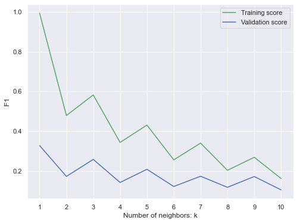

| rank_test_score | mean_train_score | mean_test_score | params |
| --- | --- | --- | --- |
| 1 | 0.994882 | 0.327618 | {'n_neighbors': 1} |
| 2 | 0.582519 | 0.257620 | {'n_neighbors': 3} |
| 3 | 0.430603 | 0.207763 | {'n_neighbors': 5} |
| 4 | 0.339803 | 0.172783 | {'n_neighbors': 7} |
| 5 | 0.478696 | 0.171738 | {'n_neighbors': 2} |
| 6 | 0.268284 | 0.171297 | {'n_neighbors': 9} |
| 7 | 0.343126 | 0.141347 | {'n_neighbors': 4} |
| 8 | 0.255289 | 0.121026 | {'n_neighbors': 6} |
| 9 | 0.202672 | 0.116993 | {'n_neighbors': 8} |
| 10 | 0.161121 | 0.103941 | {'n_neighbors': 10} |

```python
k_range = list(range(1, 11))
param_grid = {'n_neighbors': k_range}

knn = KNeighborsClassifier()
knn_clf = GridSearchCV(knn,
                       param_grid,
                       scoring='f1',
                       return_train_score=True)
knn_clf.fit(X_train, y_train)

# view the complete results
results = pd.DataFrame(knn_clf.cv_results_)
test_scores = np.array(results.mean_test_score)
train_scores = np.array(results.mean_train_score)
x_axis = k_range

# plot the mean cross-validation scores
plt.figure(figsize=(8, 6))
plt.plot(x_axis, train_scores, label='Training score', c='g')
plt.plot(x_axis, test_scores, label='Validation score', c='b')
plt.xlabel('Number of neighbors: k')
plt.ylabel(knn_clf.scoring.capitalize())
plt.xticks(range(1, len(k_range) + 1), k_range)
plt.legend()
plt.show()

results.set_index(['rank_test_score']).sort_index()[[
    'mean_train_score', 'mean_test_score', 'params'
]]
```

```python
y_pred = knn_clf.predict(X_test)

print('The accuracy score: {}'.format(accuracy_score(y_test, y_pred)))
print('The precision score: {}'.format(precision_score(y_test, y_pred)))
print('The recall score: {}'.format(recall_score(y_test, y_pred)))
print('The f1 score: {}'.format(f1_score(y_test, y_pred)))
print('The auc score: {}'.format(roc_auc_score(y_test, y_pred)))
```

```
The accuracy score: 0.723
The precision score: 0.32051282051282054
The recall score: 0.38860103626943004
The f1 score: 0.351288056206089
The auc score: 0.5957875069822987
```

### Logistic Regression

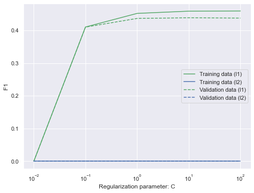

| rank_test_score | mean_train_score | mean_test_score | params |
| --- | --- | --- | --- |
| 1 | 0.458801 | 0.438568 | {'C': 10, 'penalty': 'l1'} |
| 2 | 0.459384 | 0.437641 | {'C': 100, 'penalty': 'l1'} |
| 3 | 0.451953 | 0.436589 | {'C': 1, 'penalty': 'l1'} |
| 4 | 0.410401 | 0.410047 | {'C': 0.1, 'penalty': 'l1'} |
| 5 | 0.000000 | 0.000000 | {'C': 0.01, 'penalty': 'l1'} |
| 5 | 0.000000 | 0.000000 | {'C': 0.01, 'penalty': 'l2'} |
| 5 | 0.000000 | 0.000000 | {'C': 0.1, 'penalty': 'l2'} |
| 5 | 0.000000 | 0.000000 | {'C': 1, 'penalty': 'l2'} |
| 5 | 0.000000 | 0.000000 | {'C': 10, 'penalty': 'l2'} |
| 5 | 0.000000 | 0.000000 | {'C': 100, 'penalty': 'l2'} |

```python
c_range = [0.01, 0.1, 1, 10, 100]
param_grid = {'C': c_range, 'penalty': ['l1', 'l2']}

logreg = LogisticRegression(solver='liblinear')
logreg_clf = GridSearchCV(logreg,
                          param_grid,
                          scoring='f1',
                          return_train_score=True)
logreg_clf.fit(X_train, y_train)

# view the complete results
results = pd.DataFrame(logreg_clf.cv_results_)
test_scores = np.array(results.mean_test_score).reshape(5, 2)
train_scores = np.array(results.mean_train_score).reshape(5, 2)
x_axis = c_range

# plot the mean cross-validation scores
plt.figure(figsize=(8, 6))
plt.plot(x_axis, train_scores[:, 0], label='Training data (l1)', color='g')
plt.plot(x_axis, train_scores[:, 1], label='Training data (l2)', color='b')
plt.plot(x_axis, test_scores[:, 0], label='Validation data (l1)', color='g', linestyle='dashed')
plt.plot(x_axis, test_scores[:, 1], label='Validation data (l2)', color='b', linestyle='dashed')
plt.legend()
plt.xscale('log')
plt.xlabel('Regularization parameter: C')
plt.ylabel(logreg_clf.scoring.capitalize())
plt.show()

results.set_index(['rank_test_score']).sort_index()[[
    'mean_train_score', 'mean_test_score', 'params'
]]
```

```python
y_pred = logreg_clf.predict(X_test)

print('The accuracy score: {}'.format(accuracy_score(y_test, y_pred)))
print('The precision score: {}'.format(precision_score(y_test, y_pred)))
print('The recall score: {}'.format(recall_score(y_test, y_pred)))
print('The f1 score: {}'.format(f1_score(y_test, y_pred)))
print('The auc score: {}'.format(roc_auc_score(y_test, y_pred)))
```

```
The accuracy score: 0.834
The precision score: 0.6451612903225806
The recall score: 0.31088082901554404
The f1 score: 0.4195804195804196
The auc score: 0.6349943178534969
```

### Linear Support Vector Machine

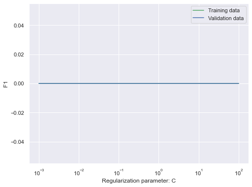

| rank_test_score | mean_train_score | mean_test_score | params |
| --- | --- | --- | --- |
| 1 | 0.0 | 0.0 | {'C': 0.001} |
| 1 | 0.0 | 0.0 | {'C': 0.01} |
| 1 | 0.0 | 0.0 | {'C': 0.1} |
| 1 | 0.0 | 0.0 | {'C': 1} |
| 1 | 0.0 | 0.0 | {'C': 10} |
| 1 | 0.0 | 0.0 | {'C': 100} |

```python
c_range = [0.001, 0.01, 0.1, 1, 10, 100]
param_grid = {'C': c_range}
lsvc = LinearSVC(dual=False, random_state=0)
lsvc_clf = GridSearchCV(lsvc,
                        param_grid,
                        scoring='f1',
                        return_train_score=True)
lsvc_clf.fit(X_train, y_train)

# view the complete results
results = pd.DataFrame(lsvc_clf.cv_results_)
test_scores = np.array(results.mean_test_score)
train_scores = np.array(results.mean_train_score)
x_axis = c_range

# plot the mean cross-validation scores
plt.figure(figsize=(8, 6))
plt.plot(x_axis, train_scores, label='Training data', c='g')
plt.plot(x_axis, test_scores, label='Validation data', c='b')
plt.legend(loc='best')
plt.xlabel('Regularization parameter: C')
plt.ylabel(lsvc_clf.scoring.capitalize())
plt.xscale('log')
plt.show()

results.set_index(['rank_test_score']).sort_index()[[
    'mean_train_score', 'mean_test_score', 'params'
]]
```

```python
y_pred = lsvc_clf.predict(X_test)

print('The accuracy score: {}'.format(accuracy_score(y_test, y_pred)))
print('The precision score: {}'.format(precision_score(y_test, y_pred)))
print('The recall score: {}'.format(recall_score(y_test, y_pred)))
print('The f1 score: {}'.format(f1_score(y_test, y_pred)))
print('The auc score: {}'.format(roc_auc_score(y_test, y_pred)))
```

```
The accuracy score: 0.807
The precision score: 0.0
The recall score: 0.0
The f1 score: 0.0
The auc score: 0.5
```

### Kerenilzed Support Vector Machine

#### linear

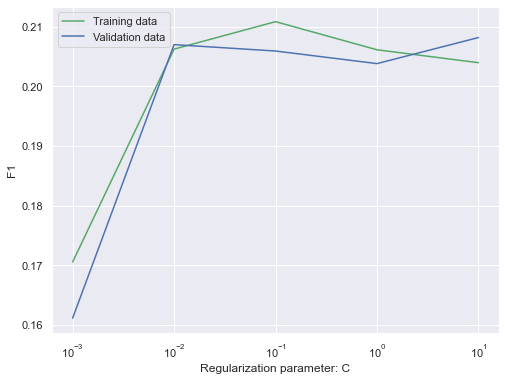

| rank_test_score | mean_train_score | mean_test_score | params |
| --- | --- | --- | --- |
| 1 | 0.203971 | 0.208186 | {'C': 10} |
| 2 | 0.206245 | 0.206996 | {'C': 0.01} |
| 3 | 0.210851 | 0.205928 | {'C': 0.1} |
| 4 | 0.206135 | 0.203816 | {'C': 1} |
| 5 | 0.170547 | 0.161134 | {'C': 0.001} |

```python
c_range = [0.001, 0.01, 0.1, 1, 10]
param_grid = {'C': c_range}
svc_linear = SVC(kernel='linear', random_state=0)
svc_linear_clf = GridSearchCV(svc_linear,
                              param_grid,
                              scoring='f1',
                              return_train_score=True,
                              n_jobs=-1)
svc_linear_clf.fit(X_train, y_train)

# view the complete results
results = pd.DataFrame(svc_linear_clf.cv_results_)
test_scores = np.array(results.mean_test_score)
train_scores = np.array(results.mean_train_score)
x_axis = c_range

# plot the mean cross-validation scores
plt.figure(figsize=(8, 6))
plt.plot(x_axis, train_scores, label='Training data', c='g')
plt.plot(x_axis, test_scores, label='Validation data', c='b')
plt.legend()
plt.xlabel('Regularization parameter: C')
plt.ylabel(svc_linear_clf.scoring.capitalize())
plt.xscale('log')
plt.show()

results.set_index(['rank_test_score']).sort_index()[[
    'mean_train_score', 'mean_test_score', 'params'
]]
```

```python
y_pred = svc_linear_clf.predict(X_test)

print('The accuracy score: {}'.format(accuracy_score(y_test, y_pred)))
print('The precision score: {}'.format(precision_score(y_test, y_pred)))
print('The recall score: {}'.format(recall_score(y_test, y_pred)))
print('The f1 score: {}'.format(f1_score(y_test, y_pred)))
print('The auc score: {}'.format(roc_auc_score(y_test, y_pred)))
```

```
The accuracy score: 0.781
The precision score: 0.3645833333333333
The recall score: 0.18134715025906736
The f1 score: 0.24221453287197228
The auc score: 0.5528792752534494
```

#### rbf

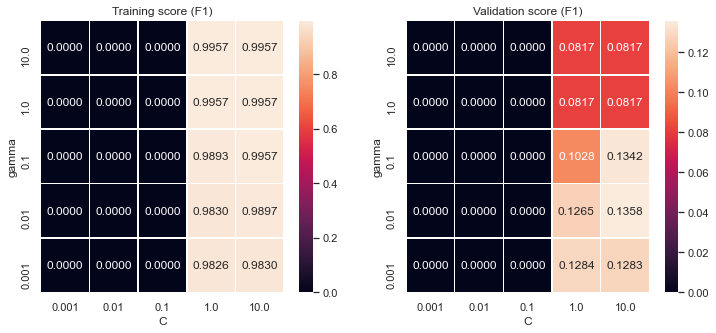

| rank_test_score | mean_train_score | mean_test_score | params |
| --- | --- | --- | --- |
| 1 | 0.989723 | 0.135794 | {'C': 10, 'gamma': 0.01} |
| 2 | 0.995692 | 0.134166 | {'C': 10, 'gamma': 0.1} |
| 3 | 0.982597 | 0.128399 | {'C': 1, 'gamma': 0.001} |
| 4 | 0.983012 | 0.128301 | {'C': 10, 'gamma': 0.001} |
| 5 | 0.983012 | 0.126499 | {'C': 1, 'gamma': 0.01} |
| 6 | 0.989278 | 0.102775 | {'C': 1, 'gamma': 0.1} |
| 7 | 0.995683 | 0.081733 | {'C': 10, 'gamma': 10} |
| 7 | 0.995683 | 0.081733 | {'C': 1, 'gamma': 10} |
| 7 | 0.995683 | 0.081733 | {'C': 1, 'gamma': 1} |
| 7 | 0.995683 | 0.081733 | {'C': 10, 'gamma': 1} |
| 11 | 0.000000 | 0.000000 | {'C': 0.1, 'gamma': 10} |
| 11 | 0.000000 | 0.000000 | {'C': 0.1, 'gamma': 1} |
| 11 | 0.000000 | 0.000000 | {'C': 0.001, 'gamma': 0.001} |
| 11 | 0.000000 | 0.000000 | {'C': 0.1, 'gamma': 0.001} |
| 11 | 0.000000 | 0.000000 | {'C': 0.01, 'gamma': 10} |
| 11 | 0.000000 | 0.000000 | {'C': 0.01, 'gamma': 1} |
| 11 | 0.000000 | 0.000000 | {'C': 0.01, 'gamma': 0.1} |
| 11 | 0.000000 | 0.000000 | {'C': 0.01, 'gamma': 0.01} |
| 11 | 0.000000 | 0.000000 | {'C': 0.01, 'gamma': 0.001} |
| 11 | 0.000000 | 0.000000 | {'C': 0.001, 'gamma': 10} |
| 11 | 0.000000 | 0.000000 | {'C': 0.001, 'gamma': 1} |
| 11 | 0.000000 | 0.000000 | {'C': 0.001, 'gamma': 0.1} |
| 11 | 0.000000 | 0.000000 | {'C': 0.001, 'gamma': 0.01} |
| 11 | 0.000000 | 0.000000 | {'C': 0.1, 'gamma': 0.01} |
| 11 | 0.000000 | 0.000000 | {'C': 0.1, 'gamma': 0.1} |

```python
param_grid = {
    'C': [0.001, 0.01, 0.1, 1, 10],
    'gamma': [0.001, 0.01, 0.1, 1, 10]
}
svc_rbf = SVC(kernel='rbf', random_state=0)
svc_rbf_clf = GridSearchCV(svc_rbf,
                           param_grid,
                           scoring='f1',
                           n_jobs=-1,
                           return_train_score=True)
svc_rbf_clf.fit(X_train, y_train)

# view the complete results
results = pd.DataFrame(svc_rbf_clf.cv_results_)
test_scores = np.array(results.mean_test_score).reshape(5, 5)
test_scores = pd.DataFrame(test_scores.T[::-1],
                           index=param_grid['gamma'][::-1],
                           columns=param_grid['C'])
train_scores = np.array(results.mean_train_score).reshape(5, 5)
train_scores = pd.DataFrame(train_scores.T[::-1],
                            index=param_grid['gamma'][::-1],
                            columns=param_grid['C'])

# plot the mean cross-validation scores
fig, axes = plt.subplots(ncols=2, nrows=1, figsize=(12, 5))

plt.sca(axes[0])
sns.heatmap(train_scores, annot=True, fmt='.4f', linewidths=.5)
plt.xlabel('C')
plt.ylabel('gamma')
plt.title('Training score ({})'.format(svc_rbf_clf.scoring.capitalize()))

plt.sca(axes[1])
sns.heatmap(test_scores, annot=True, fmt='.4f', linewidths=.5)
plt.xlabel('C')
plt.ylabel('gamma')
plt.title('Validation score ({})'.format(svc_rbf_clf.scoring.capitalize()))
plt.show()

results.set_index(['rank_test_score']).sort_index()[[
    'mean_train_score', 'mean_test_score', 'params'
]]
```

```python
y_pred = svc_rbf_clf.predict(X_test)

print('The accuracy score: {}'.format(accuracy_score(y_test, y_pred)))
print('The precision score: {}'.format(precision_score(y_test, y_pred)))
print('The recall score: {}'.format(recall_score(y_test, y_pred)))
print('The f1 score: {}'.format(f1_score(y_test, y_pred)))
print('The auc score: {}'.format(roc_auc_score(y_test, y_pred)))
```

```
The accuracy score: 0.812
The precision score: 0.6190476190476191
The recall score: 0.06735751295336788
The f1 score: 0.12149532710280374
The auc score: 0.5287221269847385
```

#### poly

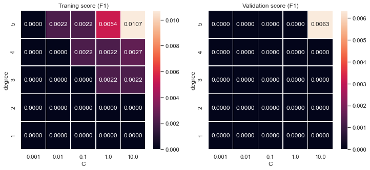

| rank_test_score | mean_train_score | mean_test_score | params |
| --- | --- | --- | --- |
| 1 | 0.010721 | 0.00635 | {'C': 10, 'degree': 5} |
| 2 | 0.002154 | 0.00000 | {'C': 10, 'degree': 3} |
| 2 | 0.000000 | 0.00000 | {'C': 10, 'degree': 2} |
| 2 | 0.000000 | 0.00000 | {'C': 10, 'degree': 1} |
| 2 | 0.005373 | 0.00000 | {'C': 1, 'degree': 5} |
| 2 | 0.002154 | 0.00000 | {'C': 1, 'degree': 4} |
| 2 | 0.002154 | 0.00000 | {'C': 1, 'degree': 3} |
| 2 | 0.000000 | 0.00000 | {'C': 1, 'degree': 2} |
| 2 | 0.000000 | 0.00000 | {'C': 1, 'degree': 1} |
| 2 | 0.002154 | 0.00000 | {'C': 0.1, 'degree': 5} |
| 2 | 0.002154 | 0.00000 | {'C': 0.1, 'degree': 4} |
| 2 | 0.002691 | 0.00000 | {'C': 10, 'degree': 4} |
| 2 | 0.000000 | 0.00000 | {'C': 0.001, 'degree': 1} |
| 2 | 0.000000 | 0.00000 | {'C': 0.1, 'degree': 1} |
| 2 | 0.002154 | 0.00000 | {'C': 0.01, 'degree': 5} |
| 2 | 0.000000 | 0.00000 | {'C': 0.01, 'degree': 4} |
| 2 | 0.000000 | 0.00000 | {'C': 0.01, 'degree': 3} |
| 2 | 0.000000 | 0.00000 | {'C': 0.01, 'degree': 2} |
| 2 | 0.000000 | 0.00000 | {'C': 0.01, 'degree': 1} |
| 2 | 0.000000 | 0.00000 | {'C': 0.001, 'degree': 5} |
| 2 | 0.000000 | 0.00000 | {'C': 0.001, 'degree': 4} |
| 2 | 0.000000 | 0.00000 | {'C': 0.001, 'degree': 3} |
| 2 | 0.000000 | 0.00000 | {'C': 0.001, 'degree': 2} |
| 2 | 0.000000 | 0.00000 | {'C': 0.1, 'degree': 2} |
| 2 | 0.000000 | 0.00000 | {'C': 0.1, 'degree': 3} |

```python
param_grid = {'C': [0.001, 0.01, 0.1, 1, 10], 'degree': [1, 2, 3, 4, 5]}
svc_poly = SVC(kernel='poly', random_state=0)
svc_poly_clf = GridSearchCV(svc_poly,
                            param_grid,
                            scoring='f1',
                            return_train_score=True,
                            n_jobs=-1)
svc_poly_clf.fit(X_train, y_train)

# view the complete results
results = pd.DataFrame(svc_poly_clf.cv_results_)
test_scores = np.array(results.mean_test_score).reshape(5, 5)
test_scores = pd.DataFrame(test_scores.T[::-1],
                           index=param_grid['degree'][::-1],
                           columns=param_grid['C'])
train_scores = np.array(results.mean_train_score).reshape(5, 5)
train_scores = pd.DataFrame(train_scores.T[::-1],
                            index=param_grid['degree'][::-1],
                            columns=param_grid['C'])

# plot the mean cross-validation scores
fig, axes = plt.subplots(ncols=2, nrows=1, figsize=(12, 5))

plt.sca(axes[0])
sns.heatmap(train_scores, annot=True, fmt='.4f', linewidths=.5)
plt.xlabel('C')
plt.ylabel('degree')
plt.title('Traning score ({})'.format(svc_poly_clf.scoring.capitalize()))

plt.sca(axes[1])
sns.heatmap(test_scores, annot=True, fmt='.4f', linewidths=.5)
plt.xlabel('C')
plt.ylabel('degree')
plt.title('Validation score ({})'.format(svc_poly_clf.scoring.capitalize()))
plt.show()

results.set_index(['rank_test_score']).sort_index()[[
    'mean_train_score', 'mean_test_score', 'params'
]]
```

```python
y_pred = svc_poly_clf.predict(X_test)

print('The accuracy score: {}'.format(accuracy_score(y_test, y_pred)))
print('The precision score: {}'.format(precision_score(y_test, y_pred)))
print('The recall score: {}'.format(recall_score(y_test, y_pred)))
print('The f1 score: {}'.format(f1_score(y_test, y_pred)))
print('The auc score: {}'.format(roc_auc_score(y_test, y_pred)))
```

```
The accuracy score: 0.805
The precision score: 0.0
The recall score: 0.0
The f1 score: 0.0
The auc score: 0.49876084262701365
```

### Decision Tree

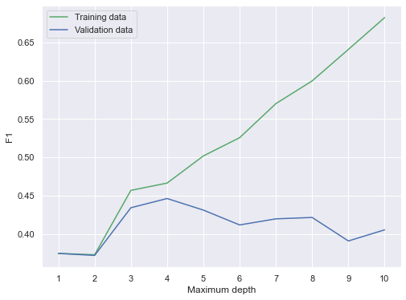

| rank_test_score | mean_train_score | mean_test_score | params |
| --- | --- | --- | --- |
| 1 | 0.466713 | 0.446609 | {'max_depth': 4} |
| 2 | 0.457228 | 0.434616 | {'max_depth': 3} |
| 3 | 0.502090 | 0.431542 | {'max_depth': 5} |
| 4 | 0.599707 | 0.421978 | {'max_depth': 8} |
| 5 | 0.570147 | 0.420143 | {'max_depth': 7} |
| 6 | 0.525799 | 0.412230 | {'max_depth': 6} |
| 7 | 0.682131 | 0.405854 | {'max_depth': 10} |
| 8 | 0.640676 | 0.391373 | {'max_depth': 9} |
| 9 | 0.375192 | 0.375131 | {'max_depth': 1} |
| 10 | 0.373425 | 0.372544 | {'max_depth': 2} |

```python
depth = list(range(1, 11))
param_grid = {'max_depth': depth}
dtree = DecisionTreeClassifier(random_state=0)
dtree_clf = GridSearchCV(dtree,
                         param_grid,
                         scoring='f1',
                         return_train_score=True)
dtree_clf.fit(X_train, y_train)

# view the complete results
results = pd.DataFrame(dtree_clf.cv_results_)
test_scores = np.array(results.mean_test_score)
train_scores = np.array(results.mean_train_score)
x_axis = depth

# plot the mean cross-validation scores
plt.figure(figsize=(8, 6))
plt.plot(x_axis, train_scores, label='Training data', c='g')
plt.plot(x_axis, test_scores, label='Validation data', c='b')
plt.xlabel('Maximum depth')
plt.ylabel(dtree_clf.scoring.capitalize())
plt.xticks(range(1, len(depth) + 1), depth)
plt.legend()
plt.show()

results.set_index(['rank_test_score']).sort_index()[[
    'mean_train_score', 'mean_test_score', 'params'
]]
```

```python
y_pred = dtree_clf.predict(X_test)

print('The accuracy score: {}'.format(accuracy_score(y_test, y_pred)))
print('The precision score: {}'.format(precision_score(y_test, y_pred)))
print('The recall score: {}'.format(recall_score(y_test, y_pred)))
print('The f1 score: {}'.format(f1_score(y_test, y_pred)))
print('The auc score: {}'.format(roc_auc_score(y_test, y_pred)))
```

```
The accuracy score: 0.818
The precision score: 0.5533980582524272
The recall score: 0.29533678756476683
The f1 score: 0.38513513513513514
The auc score: 0.619167774203697
```

## Prediction

```python
from sklearn.metrics import confusion_matrix

svc_rbf = SVC(C=10, gamma=0.01, kernel='rbf', random_state=0)
svc_rbf.fit(X_train, y_train)

y_pred = svc_rbf.predict(X_test)
confusion = confusion_matrix(y_test, y_pred)
conf_df = pd.DataFrame(confusion,
                       index=['True Negative', 'True Positive'],
                       columns=['Pred Negative', 'Pred Positive'])
TN = conf_df.iloc[0, 0]
FN = conf_df.iloc[1, 0]
FP = conf_df.iloc[0, 1]
TP = conf_df.iloc[1, 1]
acc = (TP + TN) / conf_df.sum().sum()
pre = TP / (TP + FP)
rec = TP / (TP + FN)
f1 = 2 * pre * rec / (pre + rec)
print(
    'Accuracy:{:.2%}\nPrecision:{:.2%}\nRecall:{:.2%}\nF-score:{:.2%}'.format(
        acc, pre, rec, f1))
conf_df
```

```
Accuracy:81.20%
Precision:61.90%
Recall:6.74%
F-score:12.15%
```

|  | Pred Negative | Pred Positive |
| --- | --- | --- |
| True Negative | 799 | 8 |
| True Positive | 180 | 13 |